# Reproducible Research: Peer Assessment 1

## Loading and preprocessing the data

```r
# Read in activity file
step_DF <- read.csv(file="c:/coursera/ReproducibleData/week2/activity.csv",
                    sep = ",", header=TRUE)
```

## What is mean total number of steps taken per day?

#### For this assignment ignore the missing values.

1. Calculate total daily steps.
2. Make a histogram of the total number of daily steps.
3. Calculate the mean and median of daily steps.

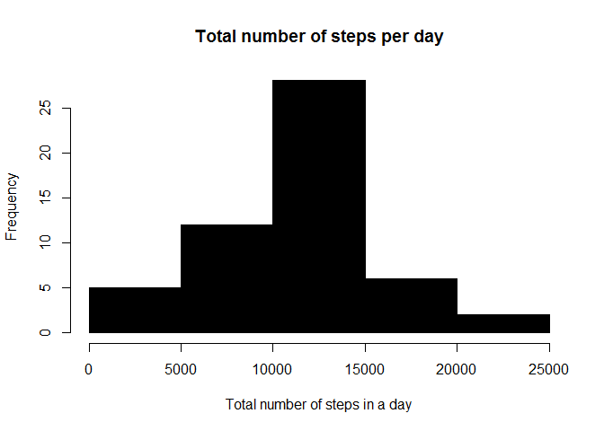

```r
# Ignore missing values
step_DF_na.omit <- na.omit(step_DF)

# Aggregate steps as per date to get total number of steps in a day
dailySteps <- aggregate(steps ~ date, step_DF_na.omit, sum)

# Create histogram of total number of steps in a day
hist(dailySteps$steps, col=1, main="Total number of steps per day", xlab="Total number of steps in a day")
```

```r
# Calculate mean and median of steps per day
meanSteps <- mean(dailySteps$steps)
meanSteps
```

```
## [1] 10766.19
```

```r
medianSteps <- median(dailySteps$steps)
medianSteps
```

```
## [1] 10765
```

```r
cat("Daily Steps mean = ", meanSteps, "and median = ", medianSteps)
```

```
## Daily Steps mean =  10766.19 and median =  10765
```

## What is the average daily activity pattern?

1. Make a time series plot (type = “l”) of the 5-minute interval (x-axis) and the average number of steps taken, averaged across all days (y-axis).
2. Which 5-minute interval contains the maximum number of steps?

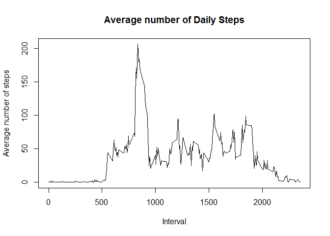

```r
# aggregate steps to get average daily interval
 internalSteps<- aggregate(steps ~ interval, step_DF_na.omit, mean)

# Plot daily average interval
plot(internalSteps$interval, internalSteps$steps, type='l', col=1,
     main="Average number of Daily Steps", xlab="Interval",
     ylab="Average number of steps")
```

```r
# Got lazy and just did which.max and max
maxSteps <- max(internalSteps$steps)
maxSteps
```

```
## [1] 206.1698
```

```r
maxInternal <- which.max(internalSteps$steps)
maxInternal
```

```
## [1] 104
```

```r
cat("5-minute interval value = ", maxInternal, "and maximum steps = ", maxSteps)
```

[output not shown]

## Imputing missing values

Note that there are a number of days/intervals where there are missing values (coded as NA). The presence of missing days may introduce bias into some calculations or summaries of the data.

```r
# get number of rows with NA's
stepCnt_NA <- sum(is.na(step_DF))

cat("The total number of NA's = ", stepCnt_NA)
```

```
## The total number of NA's =  2304
```

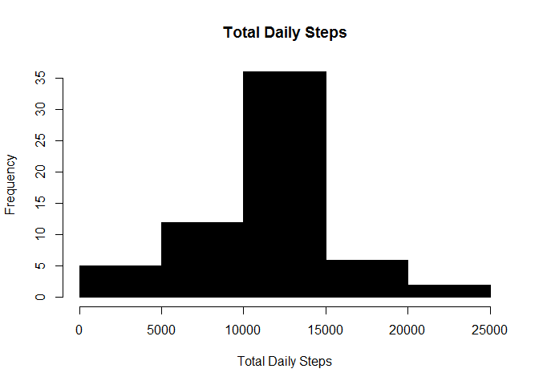

```r
# Fill in missing values
# Will use the mean for like intervals to replace NA's.
for (i in 1:nrow(step_DF))
  {
    if (is.na(step_DF$steps[i]))
      {
         rowNum <- which(internalSteps$interval == step_DF$interval[i])
         stepAvg <- round(internalSteps$steps[rowNum], digits=0)
         step_DF$steps[i] <- stepAvg
      }
  }

# Get total daily steps
dailyTotalSteps <- aggregate(steps ~ date, step_DF, sum)

# create histogram of total number of steps in a day
hist(dailyTotalSteps$steps, col=1,
    main="Total Daily Steps", xlab="Total Daily Steps")
```

```r
# Calculate mean and median of steps per day
meanTotalSteps <- mean(dailyTotalSteps$steps)
meanTotalSteps
```

```
## [1] 10765.64
```

```r
medianTotalSteps <- median(dailyTotalSteps$steps)
medianTotalSteps
```

```
## [1] 10762
```

```r
cat("Imputed: Daily Steps mean = ", meanTotalSteps, "and median = ", medianTotalSteps)
```

```
## Imputed: Daily Steps mean =  10765.64 and median =  10762
```

## Are there differences in activity patterns between weekdays and weekends?

For this part the weekdays() function may be of some help here. Use the dataset with the filled-in missing values for this part.

1. Create a new factor variable in the dataset with two levels - weekday and weekend indicating whether a given date is a weekday or weekend day. 2.Make a panel plot containing a time series plot of the 5-minute interval and the average number of steps taken, averaged across all weekday days or weekend days.

```r
# convert date from string to Date class
step_DF$date <- as.Date(step_DF$date, "%Y-%m-%d")

# day of the week
step_DF$day <- weekdays(step_DF$date)

# add a new column called day type and initialize to weekday
step_DF$dayType <- c("weekday")

# If day is Saturday or Sunday, make day type as weekend
for (i in 1:nrow(step_DF))
  {
     if (step_DF$day[i] == "Saturday" || step_DF$day[i] == "Sunday")
       {
         step_DF$dayType[i] <- "weekend"
       }
  }

# convert from character to factor
step_DF$dayType <- as.factor(step_DF$dayType)

# aggregate steps as interval to get average number of steps in an interval across all days
intervalStepsImpute <- aggregate(steps ~ interval+dayType, step_DF, mean)
```

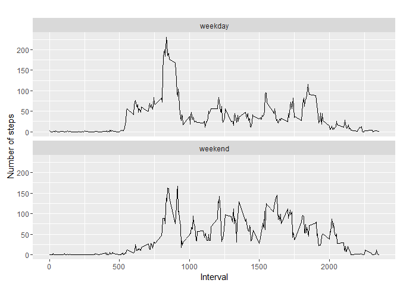

```r
# make the panel plot for weekdays and weekends
library(ggplot2)
qplot(interval, steps, data=intervalStepsImpute, geom=c("line"), xlab="Interval",
      ylab="Number of steps", main="") + facet_wrap(~ dayType, ncol=1)
```